# Exploratory data analysis of the Kennebec River discharge rates

Manny Gimond

> What follows is an example of an exploratory analysis of the Kennebec River (Maine, USA) discharge rates over time. This analysis is conducted in the spirit of [John Tukey](https://en.wikipedia.org/wiki/John_Tukey) in that it leverages both re-expression and robustness in teasing out trends in the data.

> The data were pulled from the USGS. The gage station site id is `01049500` and is located in [Gardiner , Maine (USA)](https://waterdata.usgs.gov/monitoring-location/01049500/#parameterCode=00065&period=P7D). The data span the years 1976 through 2024.

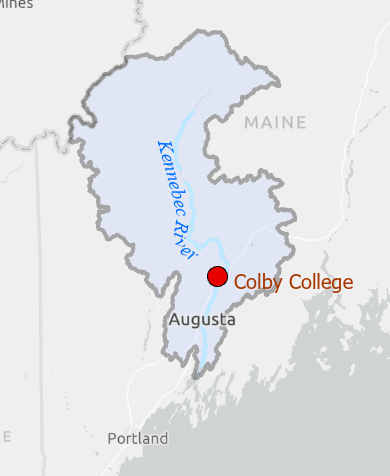

```r
library(dplyr)
library(lubridate)
library(ggplot2)

dat <- readRDS("Kennebec.Rds")
```

## Initial plot

An initial plot of the discharge rate (in ft<sup>3</sup>/s) follows.

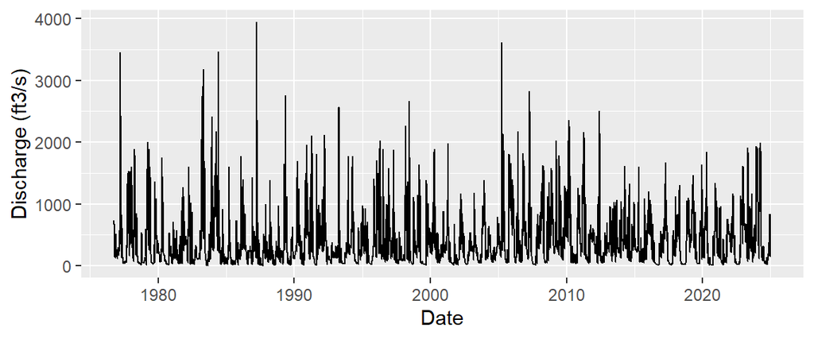

```r
ggplot(dat, aes(Date, Discharge)) + geom_line() +
  ylab("Discharge (ft3/s)")
```

The data exhibit a strong skew. We can check its distribution using a boxplot.

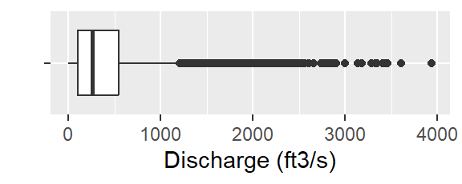

```r
ggplot(dat, aes(y = "", x = Discharge)) + geom_boxplot() + ylab("") + xlab("Discharge (ft3/s)")
```

A skewed data can bias the results of the analysis in favor of a small percentage of the observations while missing out on what the bulk of the data may be saying about the underlying process. A re-expression of the data is therefore strongly recommended.

## Re-expressing the data

A re-expression using a power of `1/5` seems to do a nice job in rendering a symmetrical distribution.

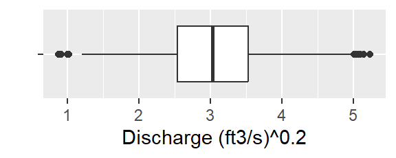

```r
dat$disp02 <- dat$Discharge^(1/5)
ggplot(dat, aes(y = "", x = disp02)) + geom_boxplot() +
  ylab("")  + xlab("Discharge (ft3/s)^0.2")
```

Note that another way to plot the distribution is to keep the original values and scale the grid.

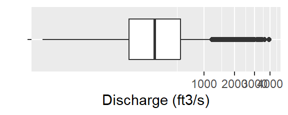

```r
ggplot(dat, aes(y = "", x = Discharge)) + geom_boxplot() + ylab("")  + coord_trans(x = scales::boxcox_trans(1/5)) +
  xlab("Discharge (ft3/s)")
```

Here’s a plot of the re-expressed discharge over time.

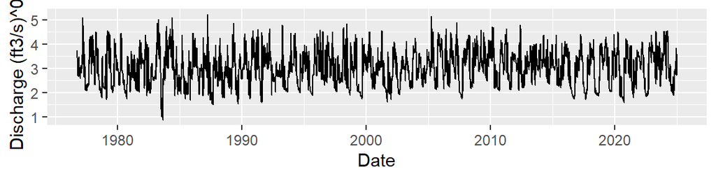

```r
ggplot(dat, aes(Date, disp02)) + geom_line() +
  ylab("Discharge (ft3/s)^0.2")
```

## Exploring an overall trend

Given that an overall trend has a variability that seems much smaller than the total variability in the data, we’ll fit a loess to help guide our choice of a parametric model. We’ll plot both a traditional loess and a robust loess.

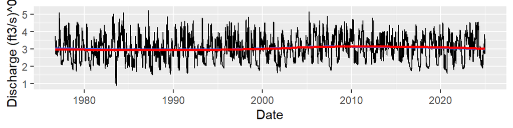

```r
ggplot(dat, aes(Date, disp02)) + geom_line() +
  ylab("Discharge (ft3/s)^0.2") +
  geom_smooth(method = "loess", se = FALSE)+
  geom_smooth(method = "loess", se = FALSE, col = "red",
              method.args = list(family = "symmetric"))
```

There is no significant difference between the traditional loess (blue line) and the robust loess (red line) which suggest that any outlier in the data does not seem to wield a disproportionate influence on the model fit.

The smooths’ shape is difficult to make out given the range of y axis values. We’ll re-plot the data using a smaller y-axis range.

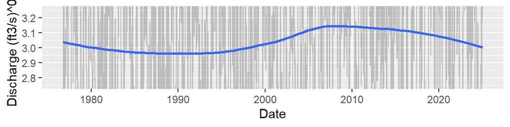

```r
ggplot(dat, aes(Date, disp02)) + geom_line(alpha = 0.2) +
  ylab("Discharge (ft3/s)^0.2") +
  geom_smooth(method = "loess", se = FALSE) +
  coord_cartesian(ylim = c(2.75, 3.25))
```

Another approach to fitting a smooth to a noisy dataset is to aggregate the data across the range of x values. In this example, we summarize the discharge values by year. We’ll use the median as the summary statistic.

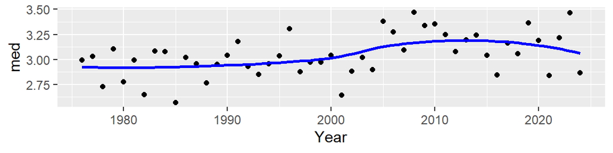

```r
dat.sub <- dat %>%
  mutate(year.int = as.integer(year(Date))) %>%
  group_by(year.int) %>%
  summarise(med = median(disp02, na.rm = TRUE))

ggplot(dat.sub, aes(year.int, med)) + geom_point() +
  geom_smooth(method = "loess", se = FALSE, col = "blue") +
  xlab("Year")
```

In both cases, the patterns appear similar with a relatively linear discharge rate between the years 1975 and 1998 and a parabolic shape between 1998 and 2024.

There are at least two approaches that can be taken in modeling our observed trend when using a parametric mode: split the data into two parts and model each trend separately (i.e. pre and post 1998), or fit an overall model. We’ll adopt the latter. This will help us quantify an “overall” change in discharge even though the change may not be monotonic across all years using. We’ll fit a 1<sup>st</sup> order polynomial model using both a regular `lm` model and the `MASS` package’s robust `rlm` model.

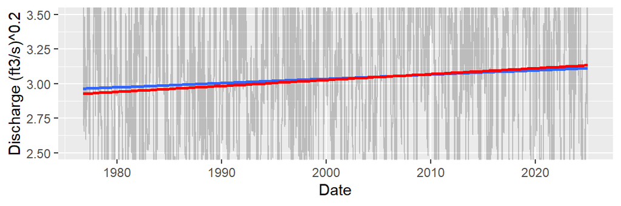

```r
ggplot(dat, aes(Date, disp02)) + geom_line(alpha = 0.2) +
  ylab("Discharge (ft3/s)^0.2") +
  geom_smooth(method = "lm", se = FALSE) +
  geom_smooth(method = MASS::rlm, se = FALSE, col = "red")  +
  coord_cartesian(ylim = c(2.5, 3.5))
```

The slopes between both the regular and robust regression models are different. This suggests that outliers in the data may be wielding a disproportionate influence on the data (this was not the case with the loess fit). We’ll adopt the robust model’s output in this analysis

```r
M1 <- MASS::rlm(disp02 ~ decimal_date(Date), dat)
```

## Exploring the residuals

To properly explore the residuals for seasonal periodicity, we need to remove any multi-year patterns in the data. This is best performed using a loess. After exploring different loess spans, a span width of 0.3 was chosen. This is a smaller span than that used earlier when we modeled the overall trend (recall that we are seeking to remove multi-year patterns in this phase of the analysis).

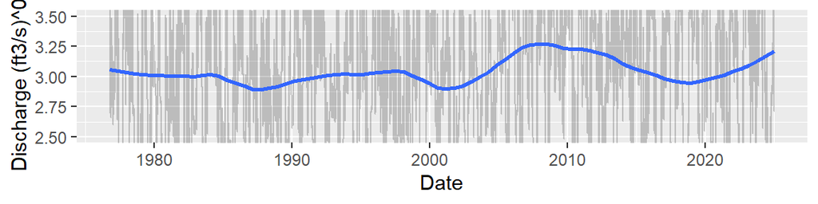

```r
ggplot(dat, aes(Date, disp02)) + geom_line(alpha = 0.2) +
  ylab("Discharge (ft3/s)^0.2") +
  geom_smooth(method = "loess", se = FALSE, span = 0.3) +
  coord_cartesian(ylim = c(2.5, 3.5))
```

```r
L1 <- loess(disp02 ~ decimal_date(Date), dat, span = 0.3)
dat$res1 <- L1$residuals
```

The residual plot follows:

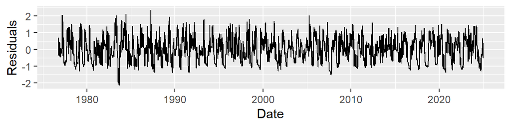

```r
ggplot(dat, aes(Date, res1)) + geom_line() +
  ylab("Residuals")
```

## Exploring annual periodicity

The following plot groups the data by month of the year.

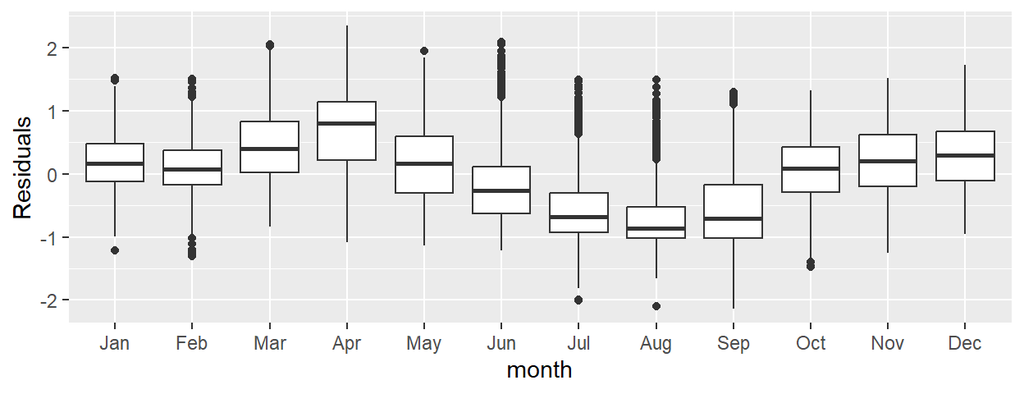

```r
dat$month <- month(dat$Date, label = TRUE)

ggplot(dat, aes(month, res1)) + geom_boxplot() +
  ylab("Residuals")
```

## Monthly trends

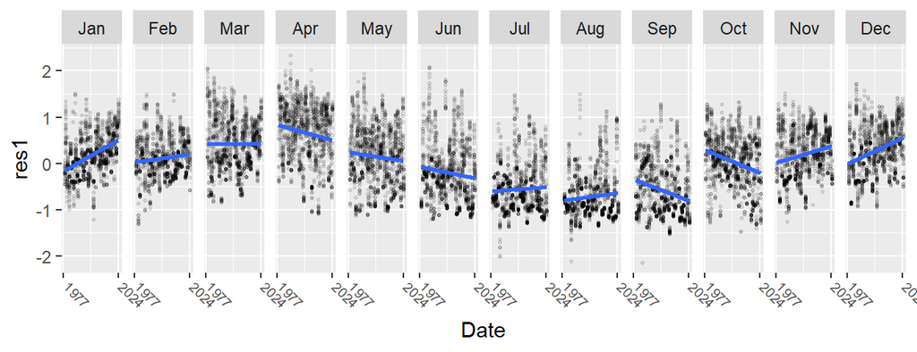

```r
ggplot(dat, aes(Date, res1)) + geom_point(alpha = 0.1, cex = 0.5) +
  facet_wrap(~ month, nrow = 1) +
  geom_smooth(method = "lm", se = FALSE,
              method.args = list(family = "symmetric")) +
  scale_x_continuous(breaks = c(as.Date("1976-1-1"), as.Date("2024-1-1")), label = c("1977", "2024")) +
  theme(axis.text.x.bottom = element_text(angle = -45, size = 7, hjust = -0.3))
```

There seems to be an uptick in the rates of discharge for the winter months and a decrease in discharge for the spring months. This suggests an increase in amplitude for the winter/spring months, or an offset in amplitude.

## What can explain the change in amplitude?

Next, we’ll create a new variable, `day`, that will give us the day of the year. This will allow us to construct a three dimensional dataset with day and year mapped to the x and y axes respectively, and the residuals mapped to the z axis. The latter will be visualized using either contours or filled tiles (or both).

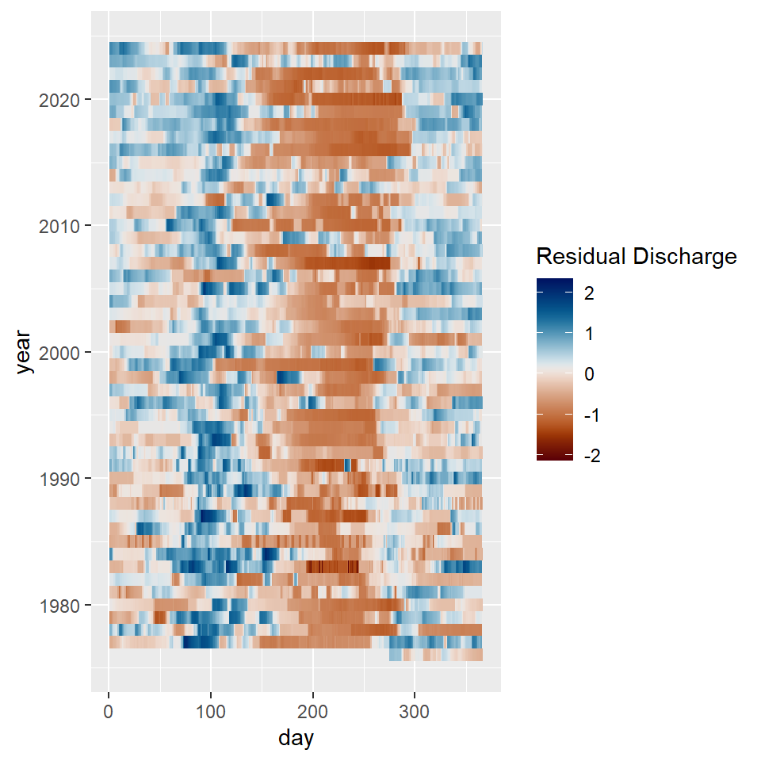

```r
# heat map of residual by day
dat.tile <- dat %>%
  group_by(year = as.integer(year(Date)), day = yday(Date)) %>%
  summarise(res1m = median(res1))


ggplot(dat.tile, aes(x = day, y = year, fill = res1m)) +
  geom_tile() +
 # scale_fill_gradient2(low="green", mid = "yellow", high = "red",
 #                      midpoint = 0)
  scico::scale_fill_scico(palette = "vik", direction = -1, name = "Residual Discharge")
```

Given that we have quite a bit of noise in the data that may be suppressing the seasonal pattern, it may be best to apply a smooth to the data. Here, we’ll adopt a loess smooth. A loess span of `0.2` is adopted to help capture small (time) scale variations on the data. To avoid edge effects at the beginning and end of each year, the data are wrapped. But wrapping is not applied to the ends of the date ranges (i.e. prior to 1976 and after 2024).

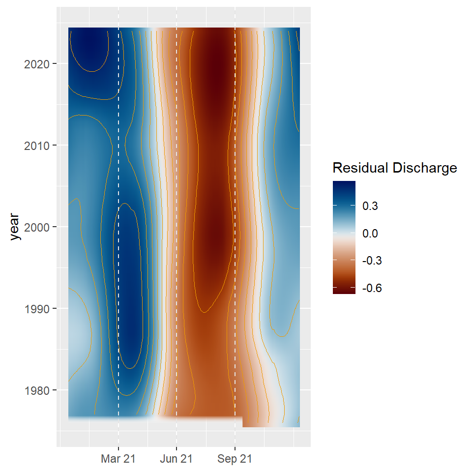

```r
dat.tile.pre <- dat.tile %>%
  filter(day > 250) %>%
  mutate(year = year + 1,
         day = day - 366)

dat.tile.post <- dat.tile %>%
  filter(day < 100) %>%
  mutate(year = year - 1,
         day = day + 366)

dat.tile.wrap <- rbind(dat.tile, dat.tile.pre, dat.tile.post)

l3d <- loess(res1m ~ year + day, dat.tile.wrap, span = 0.2,
             family = "symmetric", degree = 2)


smooth.df <- data.frame(l3d$x, l3d$fitted) %>%
  filter(day > 0 & day < 366)


#dat.tile$loess <- l3d$fitted  # Note that we are extracting the loess fitted model
                              # and not the loess residuals. But recall that the
                              # data being modeled are the discharge residuals

  ggplot(smooth.df) + aes( day , year,
                           fill = l3d.fitted,
                           z = l3d.fitted) +
  geom_raster(interpolate = TRUE) +
  scico::scale_fill_scico(palette = "vik", direction = -1, name = "Residual Discharge") +
  geom_contour(size = 0.2, color = "#EE9A00",
               breaks = seq(-0.5, 0.5, by = 0.1)) +
  geom_vline(xintercept  = c(80, 172, 264), col = "grey90", lty=2 ) +
  scale_x_continuous(breaks = c(80, 172, 264),
                     labels = c("Mar 21", "Jun 21", "Sep 21"),
                     name = NULL)
```

The smoothed surface has helped us identify a shift in spring river discharge towards earlier months (though a lull in spring discharge is observed for the time period between 2005 and 2015).

## Summary

We’ve also observed a seasonal shift towards winter months in winter/spring discharge rates. This shift is not observed for the summer and early fall months.

Note that had the analysis not been conducted on a re-expressed dataset, the results would have been biased in favor of the extreme discharge rates (see figure below). Here, the robust `lm` suggests an increase of 2.2 ft<sup>3</sup>/s per year–a much greater increase than what was observed with the re-expressed version of the data. This trend is probably more reflective of the trends in extreme discharges in the upper range of values and not the bulk of discharge values.

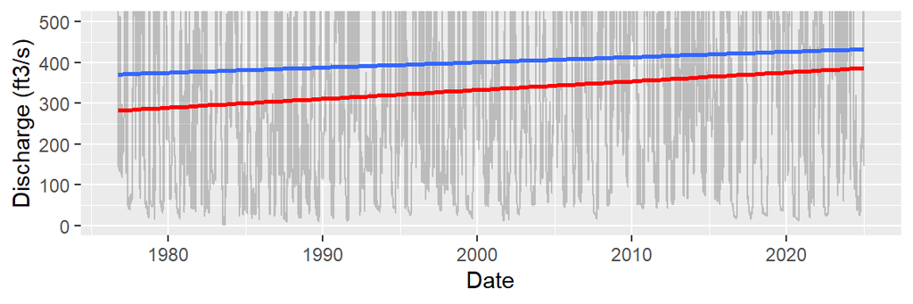

```r
ggplot(dat, aes(Date, Discharge)) + geom_line(alpha = 0.2) +
  ylab("Discharge (ft3/s)") +
  geom_smooth(method = "lm", se = FALSE)  +
  geom_smooth(method = MASS::rlm, se = FALSE, col = "red")  +
  coord_cartesian(ylim = c(0,500))
```